# Importing Libraries

```python
import numpy as np
import pandas as pd
import matplotlib.pyplot as plt
import os
import warnings
warnings.filterwarnings("ignore")
```

# Data Preparation

2.1.Write a python program to load data into pandas DataFrame

```python
_files=os.listdir(r"C:\Users\HP")
_files
```

[output not shown]

[output cut: 23 more lines]

[output not shown]

```python
csv_files = os.listdir(r"C:\Users\Hp\Salary_Analysis")
csv_files
```

```
['.ipynb_checkpoints',
 '22067323_RasikKayastha.ipynb',
 'boxplot.png',
 'BOXXPLOT.png',
 'DataScienceSalaries.csv',
 'highest_salary.png',
 'hsitogram.png',
 'salary_by_expLevel.png',
 'top_15_jobs.png']
```

```python
df = pd.read_csv(r"C:\Users\Hp\Salary_Analysis\DataScienceSalaries.csv")
```

```python
df.head(5)
```

|  | work_year | experience_level | employment_type | job_title | salary | salary_currency | salary_in_usd | employee_residence | remote_ratio | company_location | company_size |
| --- | --- | --- | --- | --- | --- | --- | --- | --- | --- | --- | --- |
| 0 | 2023 | SE | FT | Principal Data Scientist | 80000 | EUR | 85847 | ES | 100 | ES | L |
| 1 | 2023 | MI | CT | ML Engineer | 30000 | USD | 30000 | US | 100 | US | S |
| 2 | 2023 | MI | CT | ML Engineer | 25500 | USD | 25500 | US | 100 | US | S |
| 3 | 2023 | SE | FT | Data Scientist | 175000 | USD | 175000 | CA | 100 | CA | M |
| 4 | 2023 | SE | FT | Data Scientist | 120000 | USD | 120000 | CA | 100 | CA | M |

```python
df.info() ##Data Understnding with types
```

```
<class 'pandas.core.frame.DataFrame'>
RangeIndex: 3755 entries, 0 to 3754
Data columns (total 11 columns):
 #   Column              Non-Null Count  Dtype
---  ------              --------------  -----
 0   work_year           3755 non-null   int64
 1   experience_level    3755 non-null   object
 2   employment_type     3755 non-null   object
 3   job_title           3755 non-null   object
 4   salary              3755 non-null   int64
 5   salary_currency     3755 non-null   object
 6   salary_in_usd       3755 non-null   int64
 7   employee_residence  3755 non-null   object
 8   remote_ratio        3755 non-null   int64
 9   company_location    3755 non-null   object
 10  company_size        3755 non-null   object
dtypes: int64(4), object(7)
memory usage: 322.8+ KB
```

2.2.Write a python program to remove unnecessary columns i.e., salary and salary currency.

```python
#drop function to drop unnecessary columns
df.drop(['salary', 'salary_currency'], axis=1, inplace=True)
```

```python
df.head()
```

|  | work_year | experience_level | employment_type | job_title | salary_in_usd | employee_residence | remote_ratio | company_location | company_size |
| --- | --- | --- | --- | --- | --- | --- | --- | --- | --- |
| 0 | 2023 | SE | FT | Principal Data Scientist | 85847 | ES | 100 | ES | L |
| 1 | 2023 | MI | CT | ML Engineer | 30000 | US | 100 | US | S |
| 2 | 2023 | MI | CT | ML Engineer | 25500 | US | 100 | US | S |
| 3 | 2023 | SE | FT | Data Scientist | 175000 | CA | 100 | CA | M |
| 4 | 2023 | SE | FT | Data Scientist | 120000 | CA | 100 | CA | M |

2.3.Write a python program to remove the NaN missing values from updated dataframe.

```python
df.isna() #checking missing values in the dataset
```

|  | work_year | experience_level | employment_type | job_title | salary_in_usd | employee_residence | remote_ratio | company_location | company_size |
| --- | --- | --- | --- | --- | --- | --- | --- | --- | --- |
| 0 | False | False | False | False | False | False | False | False | False |
| 1 | False | False | False | False | False | False | False | False | False |
| 2 | False | False | False | False | False | False | False | False | False |
| 3 | False | False | False | False | False | False | False | False | False |
| 4 | False | False | False | False | False | False | False | False | False |
| ... | ... | ... | ... | ... | ... | ... | ... | ... | ... |
| 3750 | False | False | False | False | False | False | False | False | False |
| 3751 | False | False | False | False | False | False | False | False | False |
| 3752 | False | False | False | False | False | False | False | False | False |
| 3753 | False | False | False | False | False | False | False | False | False |
| 3754 | False | False | False | False | False | False | False | False | False |

3755 rows × 9 columns

```python
#calculating missing values in the dataset
missing_val = df.isna().sum()
missing_val
```

```
work_year             0
experience_level      0
employment_type       0
job_title             0
salary_in_usd         0
employee_residence    0
remote_ratio          0
company_location      0
company_size          0
dtype: int64
```

As there are no missing values no need to remove them

If there are any then we can use

```python
df.dropna(inplace=True) #To remove nan values from the dataframe
```

2.4.Write a python program to check duplicates value in the dataframe.

```python
duplicated_val = df[df.duplicated()] #To check duplicated rows present in dataframe
duplicated_val
```

|  | work_year | experience_level | employment_type | job_title | salary_in_usd | employee_residence | remote_ratio | company_location | company_size |
| --- | --- | --- | --- | --- | --- | --- | --- | --- | --- |
| 115 | 2023 | SE | FT | Data Scientist | 150000 | US | 0 | US | M |
| 123 | 2023 | SE | FT | Analytics Engineer | 289800 | US | 0 | US | M |
| 153 | 2023 | MI | FT | Data Engineer | 100000 | US | 100 | US | M |
| 154 | 2023 | MI | FT | Data Engineer | 70000 | US | 100 | US | M |
| 160 | 2023 | SE | FT | Data Engineer | 115000 | US | 0 | US | M |
| ... | ... | ... | ... | ... | ... | ... | ... | ... | ... |
| 3439 | 2022 | MI | FT | Data Scientist | 78000 | US | 100 | US | M |
| 3440 | 2022 | SE | FT | Data Engineer | 135000 | US | 100 | US | M |
| 3441 | 2022 | SE | FT | Data Engineer | 115000 | US | 100 | US | M |
| 3586 | 2021 | MI | FT | Data Engineer | 200000 | US | 100 | US | L |
| 3709 | 2021 | MI | FT | Data Scientist | 90734 | DE | 50 | DE | L |

1171 rows × 9 columns

We can see that there are 1171rows of duplicated values present

2.5.Write a python program to see the unique values from all the columns in the dataframe.

```python
df.columns
```

```
Index(['work_year', 'experience_level', 'employment_type', 'job_title',
       'salary_in_usd', 'employee_residence', 'remote_ratio',
       'company_location', 'company_size'],
      dtype='object')
```

1. Unique values of work_year

```python
df.work_year.unique()
```

```
array([2023, 2022, 2020, 2021], dtype=int64)
```

2. Unique values of experience_level

```python
df.experience_level.unique()
```

```
array(['SE', 'MI', 'EN', 'EX'], dtype=object)
```

3. Unique values of employment_type

```python
df.employment_type.unique()
```

```
array(['FT', 'CT', 'FL', 'PT'], dtype=object)
```

4. Unique values of job_title

```python
df.job_title.unique()
```

```
array(['Principal Data Scientist', 'ML Engineer', 'Data Scientist',
       'Applied Scientist', 'Data Analyst', 'Data Modeler',
       'Research Engineer', 'Analytics Engineer',
       'Business Intelligence Engineer', 'Machine Learning Engineer',
       'Data Strategist', 'Data Engineer', 'Computer Vision Engineer',
       'Data Quality Analyst', 'Compliance Data Analyst',
       'Data Architect', 'Applied Machine Learning Engineer',
       'AI Developer', 'Research Scientist', 'Data Analytics Manager',
       'Business Data Analyst', 'Applied Data Scientist',
       'Staff Data Analyst', 'ETL Engineer', 'Data DevOps Engineer',
       'Head of Data', 'Data Science Manager', 'Data Manager',
       'Machine Learning Researcher', 'Big Data Engineer',
       'Data Specialist', 'Lead Data Analyst', 'BI Data Engineer',
       'Director of Data Science', 'Machine Learning Scientist',
       'MLOps Engineer', 'AI Scientist', 'Autonomous Vehicle Technician',
       'Applied Machine Learning Scientist', 'Lead Data Scientist',
       'Cloud Database Engineer', 'Financial Data Analyst',
       'Data Infrastructure Engineer', 'Software Data Engineer',
       'AI Programmer', 'Data Operations Engineer', 'BI Developer',
       'Data Science Lead', 'Deep Learning Researcher', 'BI Analyst',
       'Data Science Consultant', 'Data Analytics Specialist',
       'Machine Learning Infrastructure Engineer', 'BI Data Analyst',
       'Head of Data Science', 'Insight Analyst',
       'Deep Learning Engineer', 'Machine Learning Software Engineer',
       'Big Data Architect', 'Product Data Analyst',
       'Computer Vision Software Engineer', 'Azure Data Engineer',
       'Marketing Data Engineer', 'Data Analytics Lead', 'Data Lead',
       'Data Science Engineer', 'Machine Learning Research Engineer',
       'NLP Engineer', 'Manager Data Management',
       'Machine Learning Developer', '3D Computer Vision Researcher',
       'Principal Machine Learning Engineer', 'Data Analytics Engineer',
       'Data Analytics Consultant', 'Data Management Specialist',
       'Data Science Tech Lead', 'Data Scientist Lead',
       'Cloud Data Engineer', 'Data Operations Analyst',
       'Marketing Data Analyst', 'Power BI Developer',
       'Product Data Scientist', 'Principal Data Architect',
       'Machine Learning Manager', 'Lead Machine Learning Engineer',
       'ETL Developer', 'Cloud Data Architect', 'Lead Data Engineer',
       'Head of Machine Learning', 'Principal Data Analyst',
       'Principal Data Engineer', 'Staff Data Scientist',
       'Finance Data Analyst'], dtype=object)
```

5. Unique values of salary_in_usd

```python
df.salary_in_usd.unique()
```

```
array([ 85847,  30000,  25500, ...,  28369, 412000,  94665], dtype=int64)
```

6. Unique values of employee_residence

```python
df.employee_residence.unique()
```

```
array(['ES', 'US', 'CA', 'DE', 'GB', 'NG', 'IN', 'HK', 'PT', 'NL', 'CH',
       'CF', 'FR', 'AU', 'FI', 'UA', 'IE', 'IL', 'GH', 'AT', 'CO', 'SG',
       'SE', 'SI', 'MX', 'UZ', 'BR', 'TH', 'HR', 'PL', 'KW', 'VN', 'CY',
       'AR', 'AM', 'BA', 'KE', 'GR', 'MK', 'LV', 'RO', 'PK', 'IT', 'MA',
       'LT', 'BE', 'AS', 'IR', 'HU', 'SK', 'CN', 'CZ', 'CR', 'TR', 'CL',
       'PR', 'DK', 'BO', 'PH', 'DO', 'EG', 'ID', 'AE', 'MY', 'JP', 'EE',
       'HN', 'TN', 'RU', 'DZ', 'IQ', 'BG', 'JE', 'RS', 'NZ', 'MD', 'LU',
       'MT'], dtype=object)
```

7. Unique values of remote_ratio

```python
df.remote_ratio.unique()
```

```
array([100,   0,  50], dtype=int64)
```

8. Unique values of company_location

```python
df.company_location.unique()
```

```
array(['ES', 'US', 'CA', 'DE', 'GB', 'NG', 'IN', 'HK', 'NL', 'CH', 'CF',
       'FR', 'FI', 'UA', 'IE', 'IL', 'GH', 'CO', 'SG', 'AU', 'SE', 'SI',
       'MX', 'BR', 'PT', 'RU', 'TH', 'HR', 'VN', 'EE', 'AM', 'BA', 'KE',
       'GR', 'MK', 'LV', 'RO', 'PK', 'IT', 'MA', 'PL', 'AL', 'AR', 'LT',
       'AS', 'CR', 'IR', 'BS', 'HU', 'AT', 'SK', 'CZ', 'TR', 'PR', 'DK',
       'BO', 'PH', 'BE', 'ID', 'EG', 'AE', 'LU', 'MY', 'HN', 'JP', 'DZ',
       'IQ', 'CN', 'NZ', 'CL', 'MD', 'MT'], dtype=object)
```

9. Unique values of company_size

```python
df.company_size.unique()
```

```
array(['L', 'S', 'M'], dtype=object)
```

2.6.Rename the experience level columns As.

SE – Senior Level

MI – Intermediate

EN – Entry Level

EX – Executive Level

```python
#Renaming the columns by using replace function and putting old name as key and new name as value in dictionary
df['experience_level'].replace({'SE':'Senior Level','MI':'Intermediate','EN':'Entry Level','EX':'Executive Level'}, inplace=True)
```

```python
df
```

|  | work_year | experience_level | employment_type | job_title | salary_in_usd | employee_residence | remote_ratio | company_location | company_size |
| --- | --- | --- | --- | --- | --- | --- | --- | --- | --- |
| 0 | 2023 | Senior Level | FT | Principal Data Scientist | 85847 | ES | 100 | ES | L |
| 1 | 2023 | Intermediate | CT | ML Engineer | 30000 | US | 100 | US | S |
| 2 | 2023 | Intermediate | CT | ML Engineer | 25500 | US | 100 | US | S |
| 3 | 2023 | Senior Level | FT | Data Scientist | 175000 | CA | 100 | CA | M |
| 4 | 2023 | Senior Level | FT | Data Scientist | 120000 | CA | 100 | CA | M |
| ... | ... | ... | ... | ... | ... | ... | ... | ... | ... |
| 3750 | 2020 | Senior Level | FT | Data Scientist | 412000 | US | 100 | US | L |
| 3751 | 2021 | Intermediate | FT | Principal Data Scientist | 151000 | US | 100 | US | L |
| 3752 | 2020 | Entry Level | FT | Data Scientist | 105000 | US | 100 | US | S |
| 3753 | 2020 | Entry Level | CT | Business Data Analyst | 100000 | US | 100 | US | L |
| 3754 | 2021 | Senior Level | FT | Data Science Manager | 94665 | IN | 50 | IN | L |

3755 rows × 9 columns

```python
df.experience_level.unique() #checking values in experience_level column
```

```
array(['Senior Level', 'Intermediate', 'Entry Level', 'Executive Level'],
      dtype=object)
```

# Data Analysis

3.1.Write a Python program to show summary statistics of sum, mean, standard deviation, skewness, and kurtosis of any chosen variable

```python
#stats of salary_in_usd using describe function
df.salary_in_usd.describe()
```

```
count      3755.000000
mean     137570.389880
std       63055.625278
min        5132.000000
25%       95000.000000
50%      135000.000000
75%      175000.000000
max      450000.000000
Name: salary_in_usd, dtype: float64
```

```python
#sum of all values in salary_in_usd column
sum_of_salary= df.salary_in_usd.sum()
print(f"The total sum of salary : {sum_of_salary}")
```

```
The total sum of salary : 516576814
```

```python
#avarage value of salary_in_usd earned
mean_salary = df.salary_in_usd.mean()
print(f"Mean of salary_in_usd : {mean_salary}")
```

```
Mean of salary_in_usd : 137570.38988015978
```

```python
#dispersion of dataset relative to its mean
std_salary = df.salary_in_usd.std()
print(f"standard deviation of salary_in_usd : {std_salary}")
```

```
standard deviation of salary_in_usd : 63055.625278224084
```

```python
#to show normal distribution i.e. +ve indicates peaked and -ve indicates flat distribution
kurt_salary = df.salary_in_usd.kurt()
print(f"Kurtosis of salary_in_usd : {kurt_salary}")
```

```
Kurtosis of salary_in_usd : 0.8340064594833612
```

```python
#0 skewness: distribution is fully symmetrical
#+ve skewness: distribution is skewed to right
#-ve skewness: distribution is skewed to left
skew_salary = df.salary_in_usd.skew()
print(f"Skewness of salary_in_usd : {skew_salary}")
```

```
Skewness of salary_in_usd : 0.5364011659712974
```

3.1.Write a Python program to calculate and show correlation of all variables.

```python
#For finding correlation data should be represented in number; count, distance, frequency of occurrences,
correlation = df.select_dtypes(include=['float64', 'int64']).corr()
print("Correlation:")
print(correlation)
```

```
Correlation:
               work_year  salary_in_usd  remote_ratio
work_year        1.00000       0.228290     -0.236430
salary_in_usd    0.22829       1.000000     -0.064171
remote_ratio    -0.23643      -0.064171      1.000000
```

```python
#word_occurrences_job = df.job_title.str.get_dummies(sep=' ')
#correlation_with_work_year = word_occurrences_job.corrwith(df.work_year / df.work_year.max())
#print(correlation_with_work_year)
```

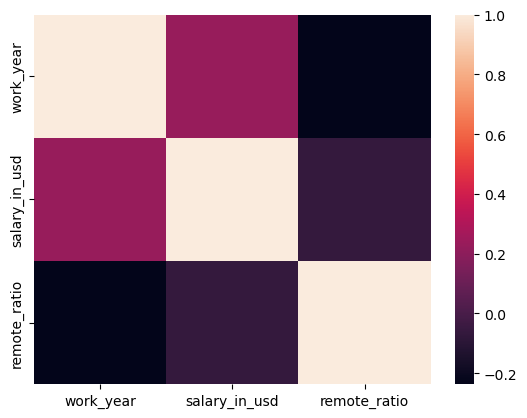

```python
#create a heatmap os correlations using seaborn
import seaborn as sns
sns.heatmap(correlation)
#remove unnecessary details and display heatmap
plt.show()
```

# Data Exploration

4.1.Write a python program to find out top 15 jobs. Make a bar graph of sales as well.

```python
# finding top 15jobs
top_15_jobs = df["job_title"].value_counts().head(15)
#finding the job with highest no of people
best_job = top_15_jobs.idxmax()
max_no =  top_15_jobs.max()
print("Top 15 jobs:")
print(top_15_jobs)
print(f"job with highest no : {best_job}")
print(f"max no of jobs in highest job: {max_no}")
```

```
Top 15 jobs:
job_title
Data Engineer                 1040
Data Scientist                 840
Data Analyst                   612
Machine Learning Engineer      289
Analytics Engineer             103
Data Architect                 101
Research Scientist              82
Data Science Manager            58
Applied Scientist               58
Research Engineer               37
ML Engineer                     34
Data Manager                    29
Machine Learning Scientist      26
Data Science Consultant         24
Data Analytics Manager          22
Name: count, dtype: int64
job with highest no : Data Engineer
max no of jobs in highest job: 1040
```

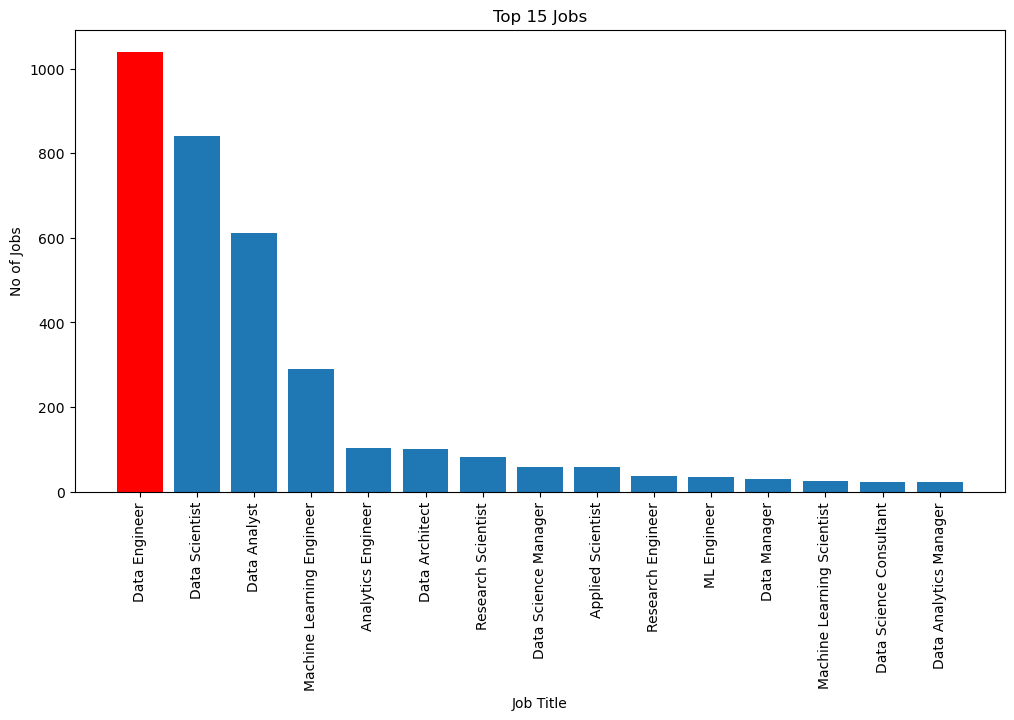

```python
# plotting in bar graph
x_title = top_15_jobs.index
y_freq = top_15_jobs.values
plt.figure(figsize=(12,6))
plt.bar(x_title,y_freq)
plt.xticks(rotation=90)
plt.title('Top 15 Jobs')
plt.xlabel('Job Title')
plt.ylabel('No of Jobs')
plt.bar(best_job,max_no,color='red') #highlighting the job with highest no
plt.savefig('top_15_jobs.png', bbox_inches='tight')
plt.show()
```

4.2.Which job has the highest salaries? Illustrate with bar graph.

```python
# finding the job with highest salary
salary_by_job =  df.groupby('job_title')['salary_in_usd'].mean()
highest_salaryjob = salary_by_job.idxmax()
max_no_salary = salary_by_job.max()
print("Salaries(USD) of each Job:")
print(salary_by_job)
print(f" \n Job with highest Salary : {highest_salaryjob}")
print(f" \n Max no of salary : {max_no_salary}")
```

```
Salaries(USD) of each Job:
job_title
3D Computer Vision Researcher     21352.250000
AI Developer                     136666.090909
AI Programmer                     55000.000000
AI Scientist                     110120.875000
Analytics Engineer               152368.631068
                                     ...
Research Engineer                163108.378378
Research Scientist               161214.195122
Software Data Engineer            62510.000000
Staff Data Analyst                15000.000000
Staff Data Scientist             105000.000000
Name: salary_in_usd, Length: 93, dtype: float64

 Job with highest Salary : Data Science Tech Lead

 Max no of salary : 375000.0
```

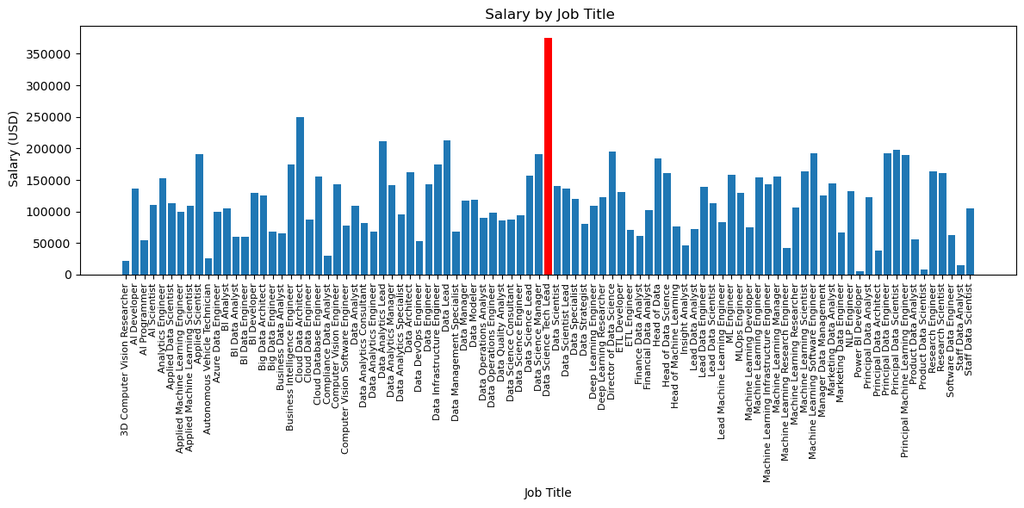

```python
# plotting the bar graph
plt.figure(figsize=(12,6))
X_title = salary_by_job.index
Y_salary = salary_by_job.values
plt.bar(X_title,Y_salary)
plt.bar(highest_salaryjob,max_no_salary,color="red")
plt.title(' Salary by Job Title')
plt.xlabel('Job Title')
plt.ylabel(' Salary (USD)')
plt.xticks(rotation=90,fontsize=8)
plt.tight_layout()
plt.savefig('highest_salary.png', bbox_inches='tight')
plt.show()
```

It can be seen that Data Science Tech Lead has the most paying stipend

4.3.Write a python program to find out salaries based on experience level. Illustrate it through bar graph.

```python
#finding salary based on exp level and the level which gets paid the most on average
salary_on_exp =  df.groupby('experience_level')['salary_in_usd'].mean()
most_paid_salary = salary_on_exp.idxmax()
max_no_sal = salary_on_exp.max()
print("Salary Based On Experience Level:")
print(salary_on_exp)
print(f" \n Most experience level who gets paid : {most_paid_salary}")
print(f"Salary paid : {max_no_salary}")
```

[output not shown]

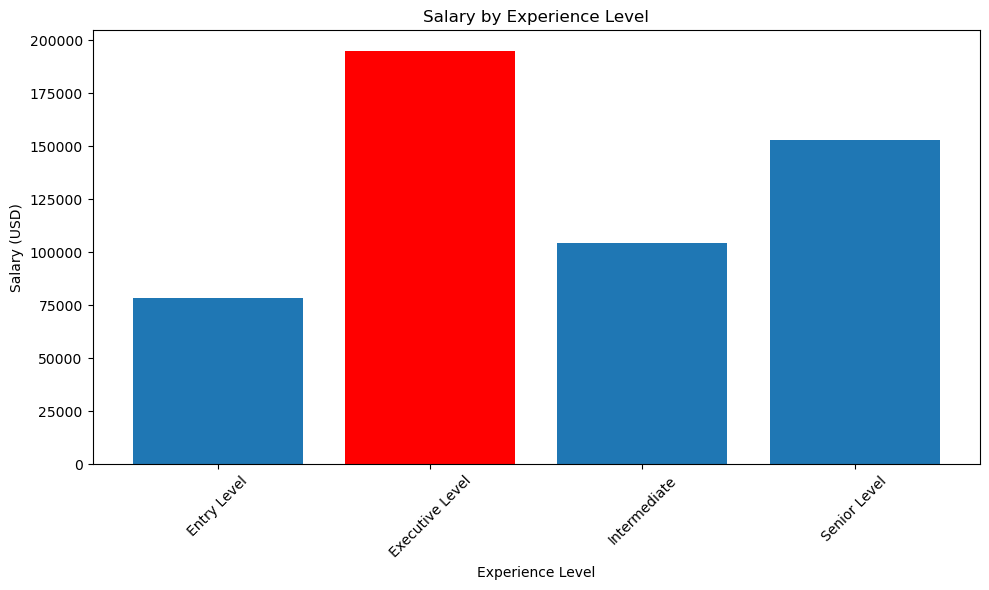

```python
#plotting in bar graph
plt.figure(figsize=(10, 6))
X = salary_on_exp.index
Y = salary_on_exp.values
plt.bar(X, Y)
plt.bar(most_paid_salary,max_no_sal,color="red") #showing the exp level with most paid salary
plt.title('Salary by Experience Level')
plt.xlabel('Experience Level')
plt.ylabel('Salary (USD)')
plt.xticks(rotation=45)
plt.tight_layout()
plt.savefig('salary_by_expLevel.png', bbox_inches='tight')
plt.show()
```

It can be seen that Executive Level gets paid more on average

4.4.Write a Python program to show histogram and box plot of any chosen different variables. Use proper labels in the graph.

#### Histogram of Salary_in_usd

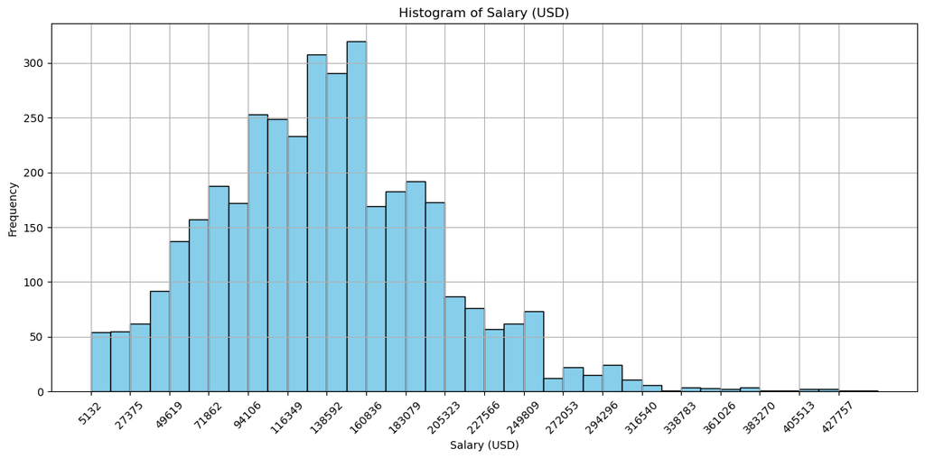

```python
min_salary = df['salary_in_usd'].min()
max_salary = df['salary_in_usd'].max()
plt.figure(figsize=(12, 6))
plt.hist(df['salary_in_usd'], bins=40,  color='skyblue', edgecolor='black')
plt.title('Histogram of Salary (USD)')
plt.xlabel('Salary (USD)')
plt.ylabel('Frequency')
plt.xticks(np.arange(min_salary, max_salary, (max_salary - min_salary) / 20), rotation=45)
plt.grid(True)
plt.tight_layout()
plt.show()
```

#### Box Plot of Salary_in_usd and Experience Level

A Box plot represents statistical five number summary i.e. minimum, Q1, Q2(median),Q3 and maximum

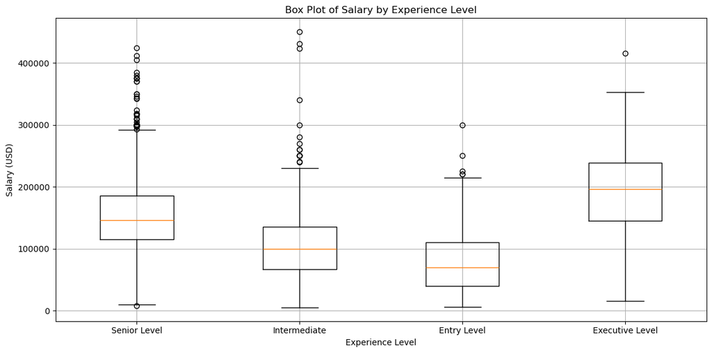

```python
plt.figure(figsize=(12, 6))
plt.boxplot([df[df['experience_level'] == 'Senior Level']['salary_in_usd'],
             df[df['experience_level'] == 'Intermediate']['salary_in_usd'],
             df[df['experience_level'] == 'Entry Level']['salary_in_usd'],
             df[df['experience_level'] == 'Executive Level']['salary_in_usd']],
            labels=['Senior Level', 'Intermediate', 'Entry Level', 'Executive Level'])
plt.title('Box Plot of Salary by Experience Level')
plt.savefig("boxplot.png")
plt.xlabel('Experience Level')
plt.ylabel('Salary (USD)')
plt.grid(True)
plt.tight_layout()
plt.show()
```